# 04 - ggplot2 - some advanced exercises

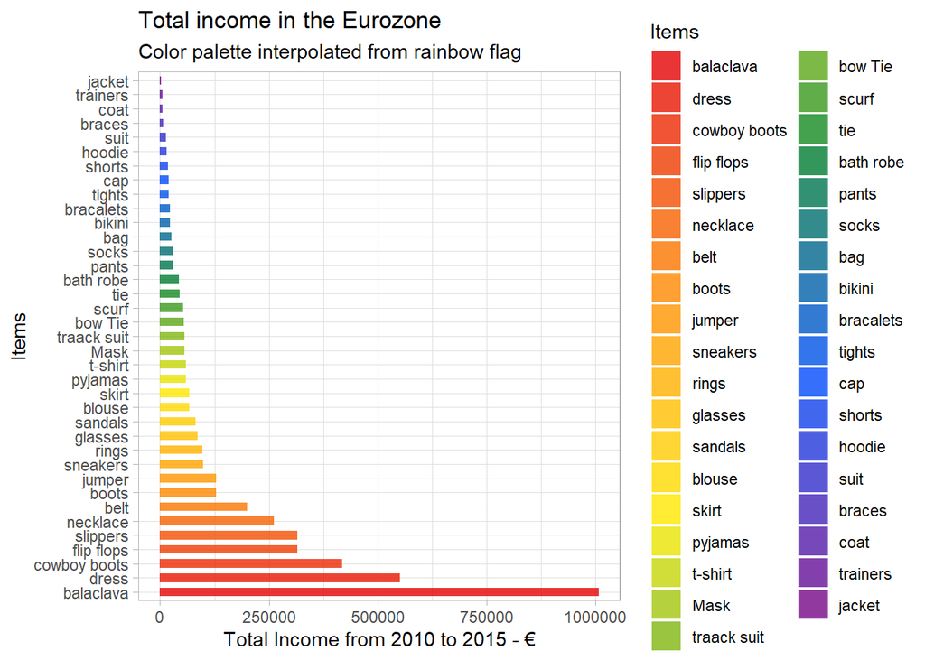

```r
# Qualitative color scale based on rainbow flag
p1 +
  scale_fill_manual(values = bar_pride_palette) +
  labs(title = "Total income in the Eurozone",
       subtitle = "Color palette interpolated from rainbow flag")
```

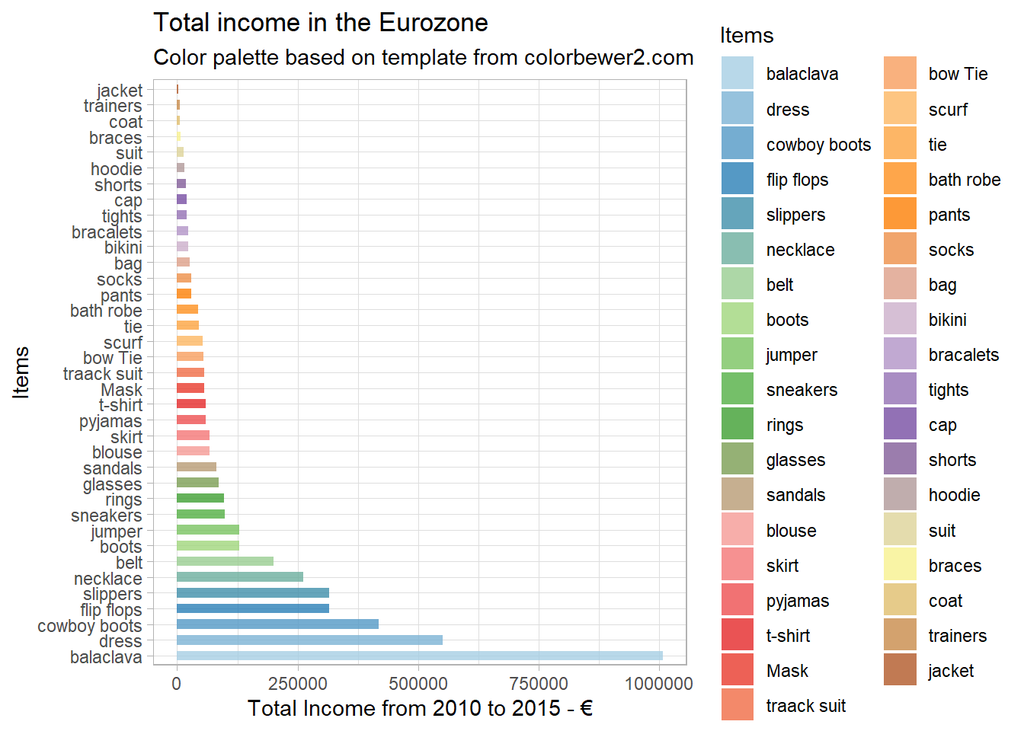

```r
# Qualitative color scale from colorbrewer2.com
p1 +
  scale_fill_manual(values = bar_alt_palette) +
  labs(title = "Total income in the Eurozone",
       subtitle = "Color palette based on template from colorbewer2.com")
```

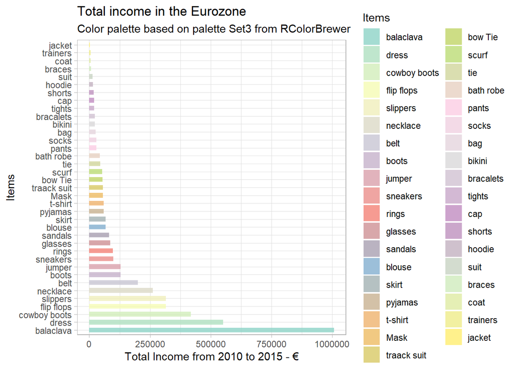

```r
# Qualitative based on Paired palette from ggplot2
p1 +
  scale_fill_manual(values = set3_palette_ext) +
  labs(title = "Total income in the Eurozone",
       subtitle = "Color palette based on palette Set3 from RColorBrewer")
```

# BP. 2 `case_when()`

Research how the function `case_when()` from the library `dplyr` (loaded along `tidyverse`) works.

Using `case_when()` and after filtering for shipments paid in Euros, classify each shipment in the following categories:

- `cheap` - `Price_per_Item` lower than 50 euros.
- `` regular`` - ``Price_per_Item` between 50 and 150 euros.
- `expensive` - `Price_per_Item` between 150 and 300 euros.
- `extra expensive` - `Price_per_Item` greater than 300 euros.

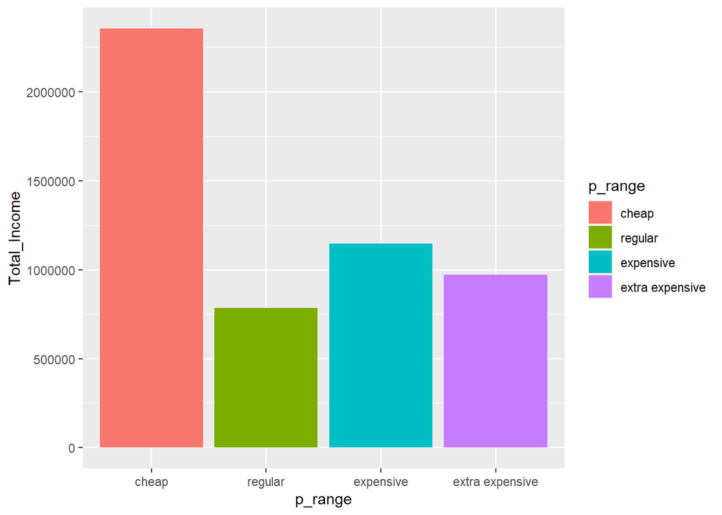

```r
aux <-
  ali %>%

    # Filter currency
    filter(Currency == "EUR") %>%

    mutate(
      # Define bin prices
      p_range = case_when(
                   Price_per_Item <= 50 ~ "cheap",
                  (Price_per_Item > 50) & (Price_per_Item <= 150) ~ "regular",
                  (Price_per_Item > 150) & (Price_per_Item <= 300) ~ "expensive",
                   Price_per_Item > 300 ~ "extra expensive"
                ),

      # Turn price range into a factor
      p_range = factor(p_range,
                       levels = c("cheap", "regular", "expensive", "extra expensive"))

    ) %>%

    # Group_by the price bins created
    group_by(p_range) %>%

    # Compute total income per price bin
    summarize(
      Total_Income = sum(Total_Income)
    )

# Produce graph
aux %>%
  ggplot(aes(x = p_range, y = Total_Income, fill = p_range)) +
  geom_bar(stat = "Identity")
```

# BP. 3

- Create a column that classifies the shipments in each country in 4 categories (you need to use `quantile()`)
  1. Shipments with a `Price_per_Item` below or equal the 25 quantile of prices - these will be `cheap`
  2. Shipments with a `Price_per_Item` between the 25 and 50 quantile of prices - these will be `regular`
  3. Shipments with a `Price_per_Item` between the 50 and 75 quantile of prices - these will be `expensive`
  4. Shipments with a `Price_per_Item` between 75 and 100 of prices - these will be `extra expensive`
- Compute
  1. The total income generated in each country for each combination of item and the price ranges above. Note that each `Item` can have multiple price ranges! (the same generic `Item` can have multiple prices)
  2. The percentege of the total income generated within the country that each combination of item and price_range represent within the country.
  3. Within each country and price range, rank order the items from greatest to lowest income generated creating a new column using `row_number`
  4. Store the result in an `aux` dataframe.

```r
aux <-
  ali %>%

    # group_by Country
    group_by(Sent_To) %>%

    mutate(

        # Define price quantiles within each country
        price_q25 = quantile(Price_per_Item, c(0.25)),
        price_q50 = quantile(Price_per_Item, c(0.5)),
        price_q75 = quantile(Price_per_Item, c(0.75)),
        price_q100 = quantile(Price_per_Item, c(1)),

        # Define price ranges within each country
        p_range = case_when(
                     Price_per_Item <= price_q25 ~ "cheap",
                    (Price_per_Item > price_q25) & (Price_per_Item <= price_q50) ~ "regular",
                    (Price_per_Item > price_q50) & (Price_per_Item <= price_q75) ~ "expensive",
                    (Price_per_Item > price_q50) & (Price_per_Item <= price_q100) ~ "extra expensive"
                  ),

        # Turn price range into a factor variable to specify ordering
        p_range = factor(p_range,
                         levels = c("cheap", "regular", "expensive", "extra expensive"))

    ) %>%

  # Compute total income for each combination of item and p_range
  # in each country
  group_by(Sent_To, Items, p_range) %>%

  summarize(
    Total_Income = sum(Total_Income)
  ) %>%

  # Compute percentage of total income that each combination of item and
  # price range represent within the country
  group_by(Sent_To) %>%

  mutate(
    perc_Country = 100 * Total_Income / sum(Total_Income)
  ) %>%

  # ungroup to prevent subsequent operations from being carried out grou-pwise
  ungroup() %>%

  # order by country (ascending), price range (ascending) and
  # Total Income (descending, greatest first)
  arrange(Sent_To, p_range, desc(Total_Income)) %>%

  # Compute row_number() (rank) given the previous ordering
  # to create a rank column
  group_by(Sent_To, p_range) %>%

  mutate(
    rank = row_number()
  )
```

Then produce the following graph indicating the percentage of total income generated by each price range for each country:

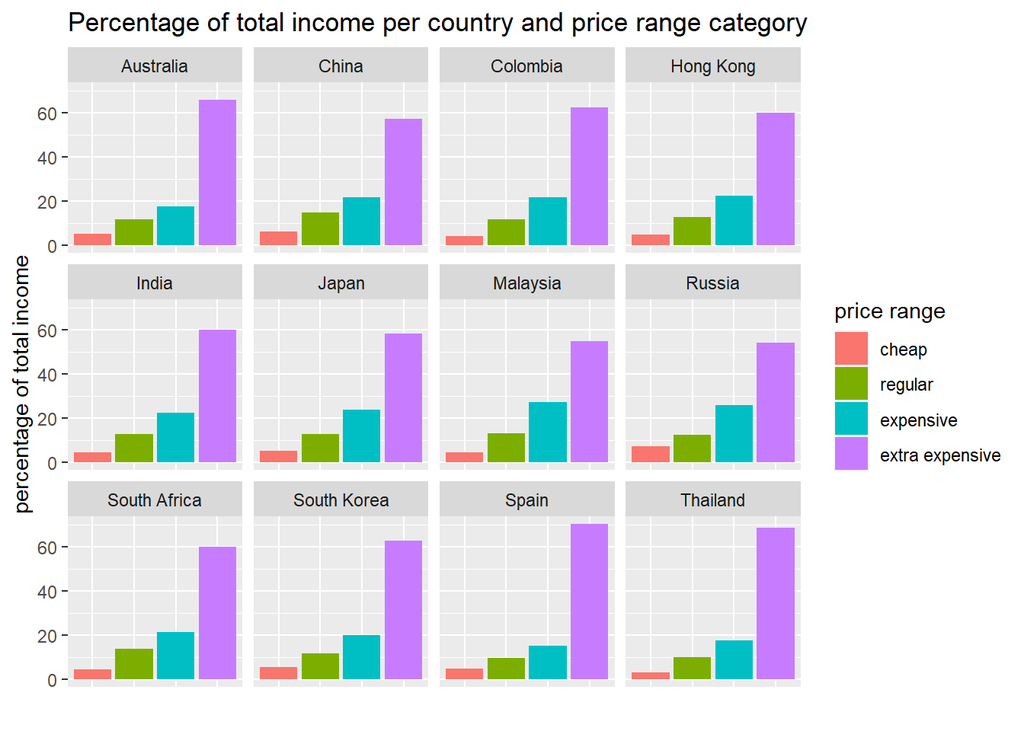

```r
p1 <- aux %>%

  group_by(Sent_To, p_range) %>%

  summarize(
    perc_Country = sum(perc_Country)
  ) %>%

  ggplot(aes(x = p_range, y = perc_Country, fill = p_range)) +
  geom_bar(stat = "Identity") +

  # Facet wrap
  facet_wrap("Sent_To") +

  ylab("percentage of total income") +
  xlab("price item category (see color legend)") +

  theme(
        axis.text.x=element_blank(), # remove text from x axis
        axis.ticks.x=element_blank(), # remove ticks from x axis
  ) +

  labs(
    title = "Percentage of total income per country and price range category",
    x = "",
    y = "percentage of total income",
    fill = "price range" # adapts the title of the legend
  )

p1
```

# BP. 4

Starting from the output of the previous question consider that, many times, most of the sales revenue is generated by small subset of products.

Using the rank column generated in the previous question, filter to have, for each country, **only the 5 items in each price category (`cheap`, `regular`, `expensive`, `extra expensive`) that generate the most income within that category**. Then aggregate their percentage contributions for each combination of country and price category and store the result in a **new auxiliar dataset called `aux_5best`. Do not delete `aux`, you need bot `aux` and `aux_5best`**.

Subsequently, add **a single `geom_point()`** layer to your previous graph to indicate where the sum of the 5 most relevant items stands within each bar (expected output below):

NOTE: specifying `data` you can feed a new dataframe to a specific `geom_()` later. You can also override the aesthetics for that particular geom specifying the aestherics as the argument `mapping`.

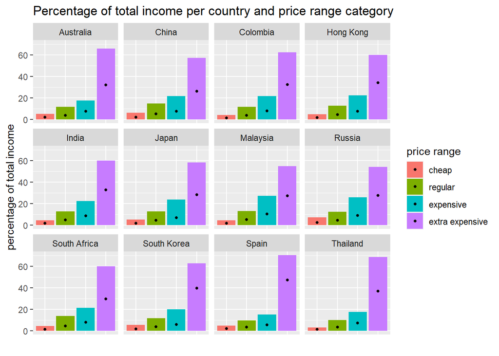

```r
aux_5best <-
  aux %>%
  filter(rank <= 5) %>%
  group_by(Sent_To, p_range) %>%
  summarize(
    perc_5best = sum(perc_Country)
  ) %>%
  ungroup()

p1 +
  # Adding a layer where we specify
  # Separately the data and the y variable
  # x variable remains the same
  geom_point(data = aux_5best,
             mapping = aes(y = perc_5best),
             size = 1)
```

# BP. 5

The previous graph is nice, but we can make it nicer. A better way to depict that information would be using dodged bar plots as in the figure below:

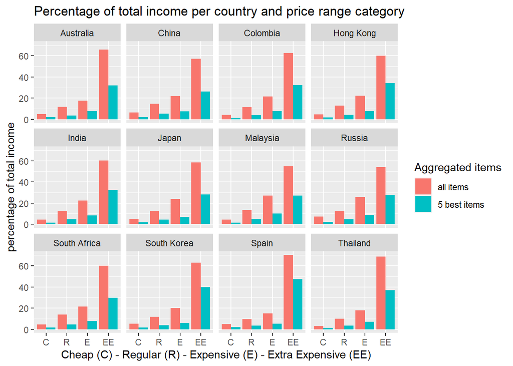

To attain this:

1. Create a new auxiliary dataframe similar to `aux_5best` but aggregate all items. Call it `aux_allitems`
2. Use `left_join()` between `aux_allitems` and `aux_5best` to produce a dataframe that looks like this (code given to you, feel free to research how left_join works):

```r
lj <- left_join(x = aux_allitems,
                y = aux_5best,
                by = c("Sent_To", "p_range"))

lj
```

```
# A tibble: 48 × 4
   Sent_To   p_range         perc_all perc_5best
   <chr>     <fct>              <dbl>      <dbl>
 1 Australia cheap               5.05       2.00
 2 Australia regular            11.6        3.67
 3 Australia expensive          17.5        7.74
 4 Australia extra expensive    65.8       32.0
 5 China     cheap               6.28       2.02
 6 China     regular            14.7        5.30
 7 China     expensive          21.8        7.57
 8 China     extra expensive    57.2       26.2
 9 Colombia  cheap               4.28       1.46
10 Colombia  regular            11.6        3.96
# … with 38 more rows
```

3. Use `pivot_longer` to go from the dataset in step 2 to a dataset that looks like this:

```r
lj %>% pivot_longer(cols = c("perc_all", "perc_5best"),
                    names_to = "perc_type",
                    values_to = "perc_country")
```

```
# A tibble: 96 × 4
   Sent_To   p_range         perc_type  perc_country
   <chr>     <fct>           <chr>             <dbl>
 1 Australia cheap           perc_all           5.05
 2 Australia cheap           perc_5best         2.00
 3 Australia regular         perc_all          11.6
 4 Australia regular         perc_5best         3.67
 5 Australia expensive       perc_all          17.5
 6 Australia expensive       perc_5best         7.74
 7 Australia extra expensive perc_all          65.8
 8 Australia extra expensive perc_5best        32.0
 9 China     cheap           perc_all           6.28
10 China     cheap           perc_5best         2.02
# … with 86 more rows
```

With that last dataframe, you should be able to produce the graph. You need to carry out some minor variable transformation and graph customization. Good luck! The solution will be printed below in the notebook with solutions.

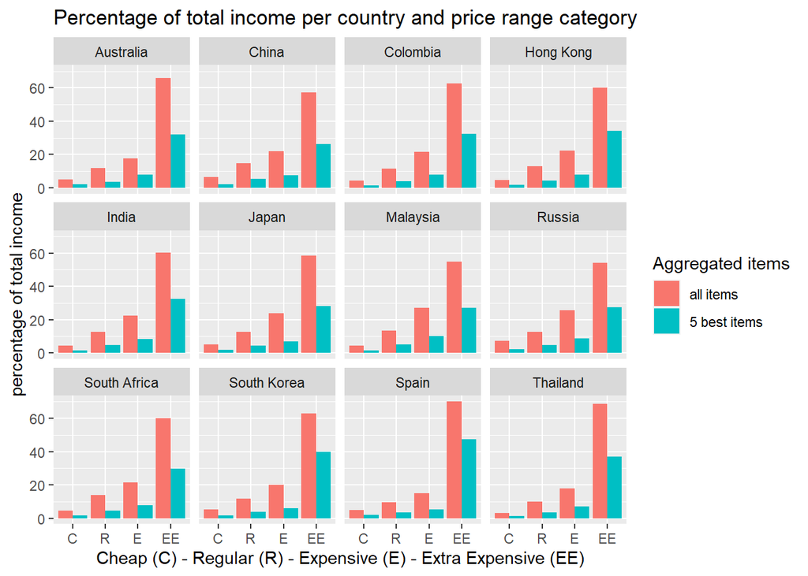

```r
aux_allitems <-
  aux %>%
  group_by(Sent_To, p_range) %>%
  summarize(
    perc_all = sum(perc_Country)
  ) %>%
  ungroup()
aux_ljoin <-

  left_join(x = aux_allitems,
            y = aux_5best,
            by = c("Sent_To", "p_range")) %>%

  pivot_longer(cols = c("perc_all", "perc_5best"),
               names_to = "perc_type",
               values_to = "perc_country") %>%

  mutate(
    perc_type = factor(perc_type,
                       levels = c("perc_all", "perc_5best"),

                       # Redefine labels for the color lagend
                       labels = c("all items", "5 best items")
                       )
  )

aux_ljoin %>%

  ggplot(aes(x = p_range, y = perc_country, fill = perc_type)) +

  geom_bar(stat = "identity", position = "dodge") +

  facet_wrap("Sent_To") +

  scale_x_discrete(labels = c("C", "R", "E", "EE")) +

  labs(
    title = "Percentage of total income per country and price range category",
    x = "Cheap (C) - Regular (R) - Expensive (E) - Extra Expensive (EE)",
    y = "percentage of total income",
    fill = "Aggregated items", # adapts the title of the legend
  )
```

# BP. 6

For each color, compute the proportion of shipments of male and female clothing.

- NOTE: I have used again `theme_light()`

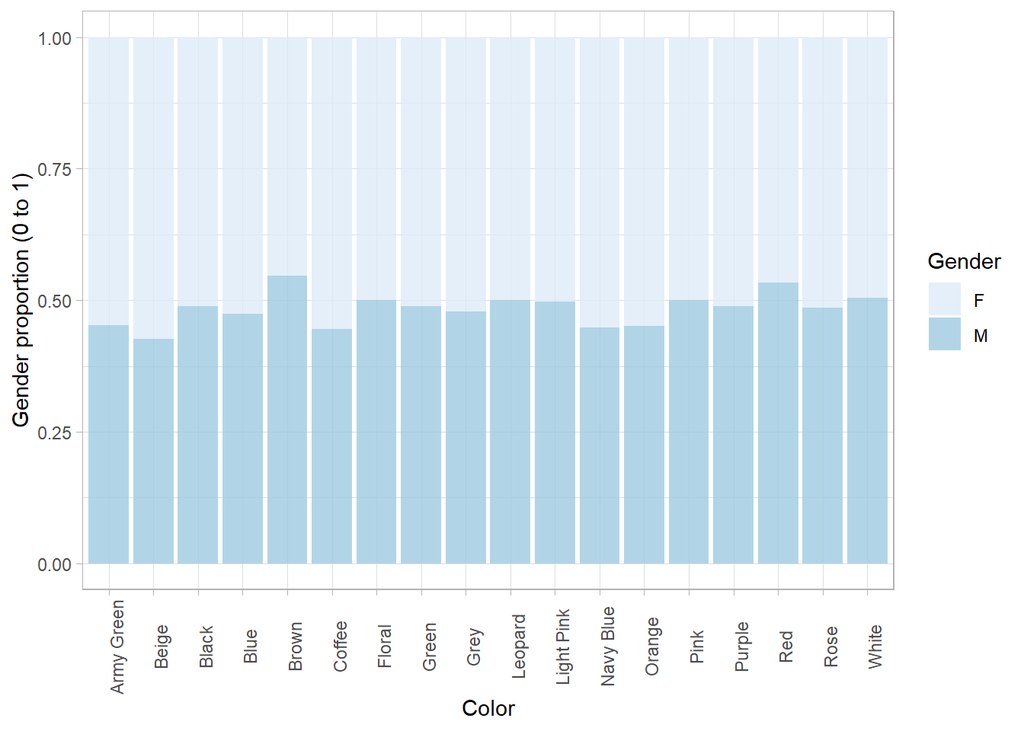

```r
ali %>%
  group_by(Color, Gender) %>%
  summarize(
    n = n()
  ) %>%

  ungroup() %>%

  ggplot(aes(x = Color, y = n, fill = Gender)) +
  geom_bar(stat = "Identity", position = "fill", alpha = 0.8) +

  scale_fill_brewer(palette = "Blues") +
  theme_light() +
  theme(
        # Change size, color and rotate x-axis labels
        axis.text.x=element_text(angle = 90),
        panel.background=element_rect(fill='white')
        ) +
  ylab("Gender proportion (0 to 1)")
```